# Replication of Figure D–F:Proximity to TSS and Binding Signal Concordance Between TAZ and TEAD4

Harshini Muthukumar

2026-03-19

### Figure 1D

Look at figure 1d, it is a scatter plot. This is the number of sequencing reads x-axis: TEAD4 signal y-axis: YAP1 signal From the figure description:

Linear correlation between the signal of YAP or TAZ and TEAD4 peaks in the 5522 shared binding sites. r2 is the coefficients of determination of the two correlations.

```r
suppressWarnings(
  suppressMessages({
    library(GenomicRanges)
    library(rtracklayer)  # for reading bed file
    library(here)
    library(dplyr)
    library(ggplot2)
    library(readr)
    library(EnsDb.Hsapiens.v86)
    library(GenomicFeatures)
    library(ggpmisc)
  })
)

TAZ_peaks<- import(here("C:/Users/harzi/OneDrive/Desktop/chip_seq_peak/TAZ_peaks.narrowPeak"))
YAP_peaks<- import(here("C:/Users/harzi/OneDrive/Desktop/chip_seq_peak/YAP_peaks.narrowPeak"))
TEAD4_peak<- import(here("C:/Users/harzi/OneDrive/Desktop/chip_seq_peak/TEAD4_peaks.narrowPeak"))

YAP_overlap_TAZ_peaks<- subsetByOverlaps(YAP_peaks, TAZ_peaks)
YAP_overlap_TAZ_peaks_overlap_TEAD4<- subsetByOverlaps(YAP_overlap_TAZ_peaks, TEAD4_peak)
```

The signal is the number of reads fall/mapped into those peaks/regions. and normalized to total number of reads (library size) for each experiment.

**bedtools multicov**, reports the count of alignments from multiple position-sorted and indexed BAM files that overlap intervals in a BED file. Specifically, for each BED interval provided, it reports a separate count of overlapping alignments from each BAM file.

```bash
cd data/fastq
bedtools multicov -bams YAP.sorted.bam TAZ.sorted.bam TEAD4.sorted.bam \
  -bed YAP_TAZ_TEAD4_common.bed > YAP_TAZ_TEAD4_counts.tsv
```

the total number of priamry mapped reads are: 23653961, 26789648 and 34332907 for YAP, TAZ and TEAD4, respectively.Using **SAMtools Flagsat** I found out this information

```r
counts<- counts %>%
  mutate(YAP1 = YAP1/23653961 * 10^6,
         TAZ = TAZ/26789648 * 10^6,
         TEAD4 = TEAD4/34332907 * 10^6)

head(counts)
```

```
## # A tibble: 6 × 9
##   chr     start     end name        score value  YAP1   TAZ TEAD4
##   <chr>   <dbl>   <dbl> <chr>       <dbl> <chr> <dbl> <dbl> <dbl>
## 1 chr1  1024627 1025059 YAP_peak_3    494 .     3.72  2.69  2.39
## 2 chr1  1264836 1265155 YAP_peak_4    148 .     1.35  1.38  2.56
## 3 chr1  1265319 1265695 YAP_peak_5    131 .     1.23  1.16  0.757
## 4 chr1  1360617 1360955 YAP_peak_6    306 .     1.94  1.94  2.56
## 5 chr1  1659297 1659586 YAP_peak_8     45 .     0.634 0.523 0.583
## 6 chr1  2061242 2061682 YAP_peak_10   356 .     2.28  2.43  1.75
```

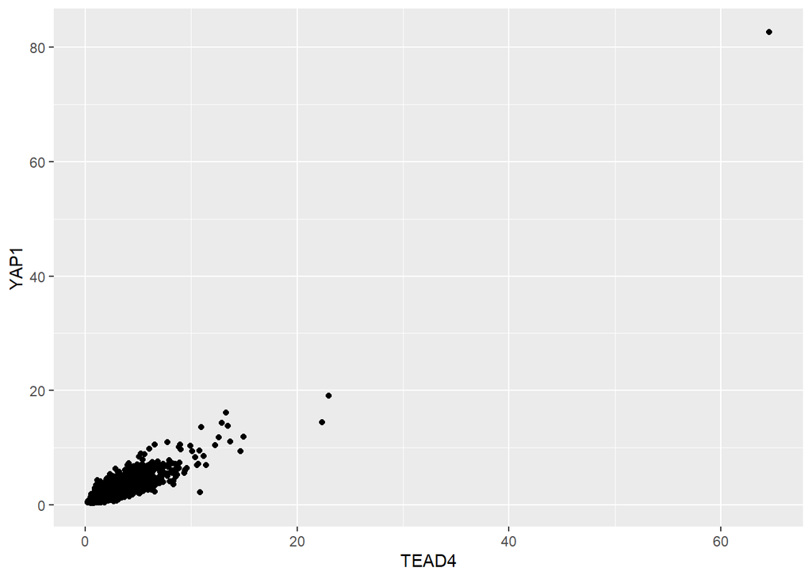

```r
ggplot(counts, aes(x=TEAD4, y= YAP1)) +
  geom_point()
```

```r
counts %>% dplyr::filter(TEAD4 > 60)
```

```
## # A tibble: 1 × 9
##   chr      start      end name          score value  YAP1   TAZ TEAD4
##   <chr>    <dbl>    <dbl> <chr>         <dbl> <chr> <dbl> <dbl> <dbl>
## 1 chr14 61754882 61755803 YAP_peak_3030  4298 .      82.6  80.3  64.5
```

There is an outlier with strong signal (checked it on IGV to see if it is real, it could be a black-listed region with strong signal).**It looks real on IGV and I checked it is not in one of the blacklisted regions**.

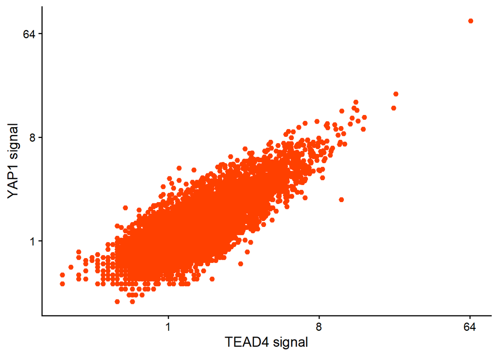

```r
ggplot(counts, aes(x=TEAD4, y= YAP1)) +
  geom_point(color = "#ff4000") +
  scale_x_continuous(trans = 'log2') +
  scale_y_continuous(trans = 'log2') +
  theme_classic(base_size = 14) +
  xlab("TEAD4 signal") +
  ylab("YAP1 signal")
```

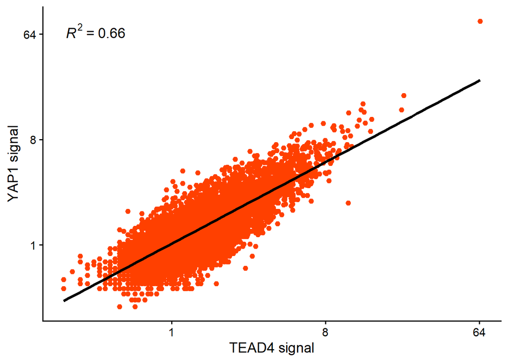

```r
ggplot(counts, aes(x=TEAD4, y= YAP1)) +
  geom_point(color = "#ff4000") +
  geom_smooth(method = "lm", se = FALSE, color = "black") +  # Linear regression line
  stat_poly_eq(
    aes(label = ..rr.label..),
    formula = y ~ x,
    parse = TRUE,
    color = "black"
  ) +
  scale_x_continuous(trans = 'log2') +
  scale_y_continuous(trans = 'log2') +
  theme_classic(base_size = 14) +
  xlab("TEAD4 signal") +
  ylab("YAP1 signal")
```

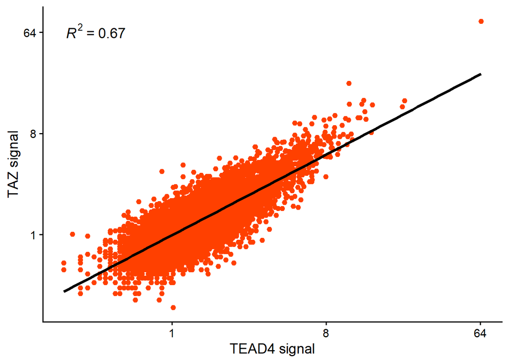

```r
ggplot(counts, aes(x=TEAD4, y= TAZ)) +
  geom_point(color = "#ff4000") +
  geom_smooth(method = "lm", se = FALSE, color = "black") +  # Linear regression line
  stat_poly_eq(
    aes(label = ..rr.label..),
    formula = y ~ x,
    parse = TRUE,
    color = "black"
  ) +
  scale_x_continuous(trans = 'log2') +
  scale_y_continuous(trans = 'log2') +
  theme_classic(base_size = 14) +
  xlab("TEAD4 signal") +
  ylab("TAZ signal")
```

The scatter plot shows a strong positive correlation between TEAD4 and TAZ binding signals across genomic regions, with an R² of 0.67, indicating that approximately 67% of the variance in TAZ signal is explained by TEAD4 signal. Both axes are on a log scale, and the linear trend holds consistently across the full range of signal intensities, suggesting that regions with high TEAD4 occupancy tend to also exhibit high TAZ binding. The spread around the regression line reflects some degree of independent binding activity — there are regions where TAZ and TEAD4 signals diverge — but the overall correlation is robust. This is consistent with the known functional relationship between TAZ and TEAD4, where TAZ acts as a transcriptional co-activator that interacts directly with TEAD family members to co-occupy regulatory elements genome-wide.

### Figure 1F

Absolute distance of YAP peaks (n=7709), TAZ peaks (n=9798), TEAD4 peaks (n=8406) or overlapping YAP/TAZ/TEAD peaks (n=5522) to the nearest TSS.

Figure 1f is a stacked bar plot. It shows the proportion of the peaks grouped by their distance to the closest TSS (transcription start site).

```r
mcols(distance_to_tss)
```

```
## DataFrame with 9802 rows and 1 column
##       distance
##      <integer>
## 1         1544
## 2         1587
## 3         4504
## 4         1267
## 5         1750
## ...        ...
## 9798      4939
## 9799     18165
## 9800      2477
## 9801      6869
## 9802      2402
```

```r
head(mcols(distance_to_tss)$distance)
```

```
## [1] 1544 1587 4504 1267 1750  821
```

[output not shown]

```r
tss_distance_df %>%
  mutate(category = case_when(
    distance < 1000 ~ "<1kb",
    distance >=1000 & distance < 10000 ~ "1-10kb",
    distance >= 10000 & distance <=100000 ~ "10-100kb",
    distance > 100000 ~ "100kb"
  )) %>%
  head()
```

```
##   factor distance category
## 1    YAP     1544   1-10kb
## 2    YAP     1587   1-10kb
## 3    YAP     4504   1-10kb
## 4    YAP     1267   1-10kb
## 5    YAP     1750   1-10kb
## 6    YAP      821     <1kb
```

```r
counts_per_category<- tss_distance_df %>%
  mutate(category = case_when(
    distance < 1000 ~ "<1kb",
    distance >=1000 & distance < 10000 ~ "1-10kb",
    distance >= 10000 & distance <=100000 ~ "10-100kb",
    distance > 100000 ~ ">100kb"
  )) %>%
  group_by(factor, category) %>%
  count()

counts_per_category
```

```
## # A tibble: 12 × 3
## # Groups:   factor, category [12]
##    factor category     n
##    <chr>  <chr>    <int>
##  1 TAZ    1-10kb    3817
##  2 TAZ    10-100kb  4741
##  3 TAZ    <1kb      1709
##  4 TAZ    >100kb     444
##  5 TEAD4  1-10kb    4121
##  6 TEAD4  10-100kb  5215
##  7 TEAD4  <1kb      1657
##  8 TEAD4  >100kb     517
##  9 YAP    1-10kb    3382
## 10 YAP    10-100kb  4204
## 11 YAP    <1kb      1843
## 12 YAP    >100kb     373
```

```r
total_counts<- tss_distance_df %>%
  mutate(category = case_when(
    distance < 1000 ~ "<1kb",
    distance >=1000 & distance < 10000 ~ "1-10kb",
    distance >= 10000 & distance <=100000 ~ "10-100kb",
    distance > 100000 ~ ">100kb"
  )) %>%
  count(factor, name = "total")

total_counts
```

```
##   factor total
## 1    TAZ 10711
## 2  TEAD4 11510
## 3    YAP  9802
```

```r
merged_df<- left_join(counts_per_category, total_counts)
```

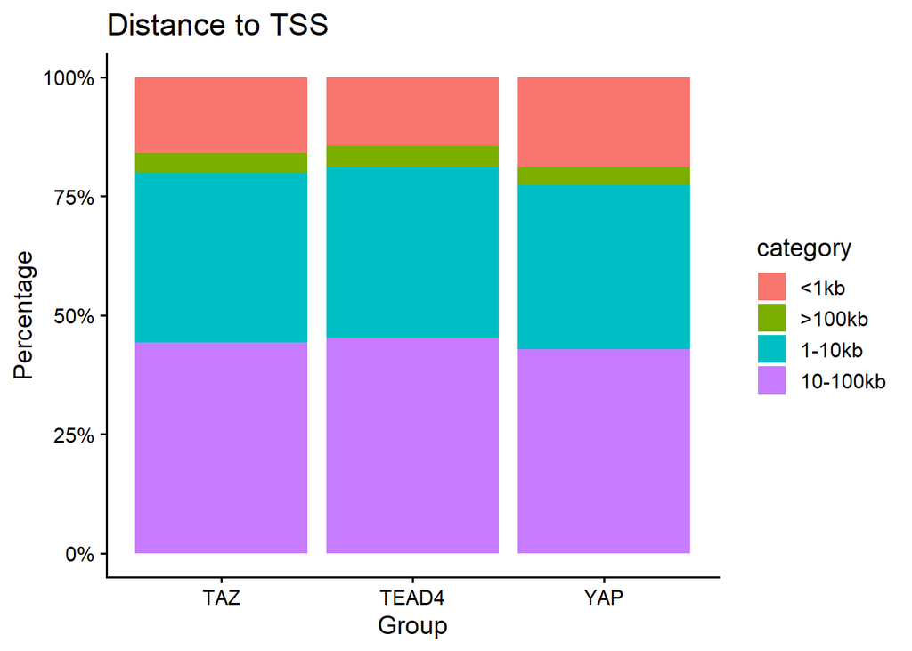

```r
merged_df %>%
  mutate(Percentage = n/total * 100) %>%
  ggplot(aes(x= factor, y = Percentage, fill = category)) +
  geom_bar(stat = "identity", position = "stack") +
  labs(
    title = "Distance to TSS",
    x = "Group",
    y = "Percentage"
  ) +
  scale_y_continuous(labels = scales::percent_format(scale = 1)) +
  theme_classic(base_size = 14)
```

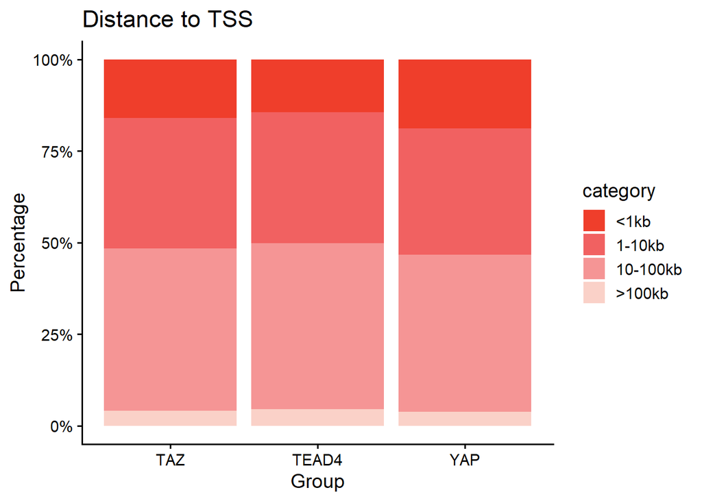

```r
merged_df$category<- factor(merged_df$category,
                            levels = c("<1kb", "1-10kb", "10-100kb", ">100kb"))
merged_df %>%
  mutate(Percentage = n/total * 100) %>%
  ggplot(aes(x= factor, y = Percentage, fill = category)) +
  geom_bar(stat = "identity", position = "stack") +
  labs(
    title = "Distance to TSS",
    x = "Group",
    y = "Percentage"
  ) +
  scale_y_continuous(labels = scales::percent_format(scale = 1)) +
  scale_fill_manual(values = c("#EF3E2B", "#F16161", "#F59595", "#FAD1C8")) +
  theme_classic(base_size = 14)
```